# PCA Thesis Pablo Corella

Jefferson Pastuña

2023-02-20

## Introducción

La raíz de la planta *Urospatha saggitifolia* es usado tradicionalmente en la Amazonía ecuatoriana para el tratamiento de accidentes ofídicos. El presente documento usará el paquete R “Notame” de [Klåvus y colaboradores (2020)](https://doi.org/10.3390%2Fmetabo10040135) para un Análisis de Componentes Pricipales (ACP) metabolómico en tres etapas de desarrollo de la planta *U. saggitifolia*.

## Métodos y resultados

Se usaron los métodos detallados en [Klåvus, et al. (2020)](https://doi.org/10.3390%2Fmetabo10040135) con algunas variaciones que se describen a continuación.

### Intalación del paquete Notame

El paquete R [“Notame”](https://github.com/antonvsdata/notame) se lo puede encuentrar en el repositorio github. A continuación, se procedió con la instalación del paquete:

```r
if (!requireNamespace("devtools", quietly = TRUE)) {
  install.packages("devtools")
}
devtools::install_github("antonvsdata/notame")
```

En este caso en particular fue necesario la intalación adicional de [RTools](https://cran.r-project.org/bin/windows/Rtools/rtools42/rtools.html) para la correcta instalaciónde del paquete Notame.

### Instalación de bibliotecas

El flujo de trabajo de Notame usa paquetes R adicionales para algunas funciones. Es por ello Notame ofrece varios instructivos de acuerdo al objetivo del usuario.

```r
# Mediante browseVignettes("notame")
```

Las bibliotecas de uso inmediato son cargadas a continuación (de ser necesario la instalación de paquetes adicionales serán requeridos y por ende la activación de su biblioteca). Previo la intalación de la biblioteca Notame se intalaron otros paquetes.

```r
if (!require("BiocManager", quietly = TRUE))
    install.packages("BiocManager")

BiocManager::install("Biobase")
library(Biobase)

if (!require("BiocManager", quietly = TRUE))
    install.packages("BiocManager")

BiocManager::install("BiocGenerics")
library(BiocGenerics)

install.packages("futile.logger", repos = "https://CRAN.R-project.org/package=futile.logger")
library(futile.logger)

if (!requireNamespace("devtools", quietly = TRUE)) {
  install.packages("devtools")
}
devtools::install_github("tidyverse/ggplot2")
library(ggplot2)

if (!requireNamespace("devtools", quietly = TRUE)) {
  install.packages("devtools")
}
devtools::install_github("tidyverse/magrittr")
library(magrittr)

library(notame)
```

De igual manera antes de la instalación de la biblioteca doParallel fue necesrio instalar paquetes adicionales.

```r
if (!requireNamespace("devtools", quietly = TRUE)) {
  install.packages("devtools")
}
devtools::install_github("RevolutionAnalytics/foreach")
library(foreach)

if (!requireNamespace("devtools", quietly = TRUE)) {
  install.packages("devtools")
}
devtools::install_github("RevolutionAnalytics/iterators")
library(iterators)

library(parallel)

install.packages("doParallel", repos="http://R-Forge.R-project.org")
library(doParallel)
```

### Carpeta de trabajo y respaldos

La ruta usada y recomendada fue la carpeta del proyecto R.

```r
ppath <- "C:/Users/F4ss0/Documents/Ikiam21062022/Tesis-Pablo-Corella/PCA-Thesis-Pablo-C/"
```

De igual manera, la ruta del respaldo de R Markdown usada fue la carpeta del proyecto R.

```r
init_log(log_file = paste0(ppath, "Result/log_preprocessing01.txt"))
```

### Importación de datos

Una vez acondicionado los datos son cargados en R de acuerdo con la documentación del paquete Notame.

```r
data <- read_from_excel(file = paste0(ppath, "Data/POS-Data-to-Notame.xlsx"), sheet = 1,
                        corner_row = 4, corner_column = "E",
                        split_by = c("Column", "Ion Mode"))
```

### Construcción de objetos con MetaboSet

A continuación, las diferentes variables serán convertidas en objetos. Donde, exprs: representa la abundancia de los picos a lo largo de las muestras (en este caso área de pico); pheno_data: agrupa información de las muestras; feature_data: agrupa información de los picos.

```r
modes <- construct_metabosets(exprs = data$exprs, pheno_data = data$pheno_data,
                             feature_data = data$feature_data,
                             group_col = "Group")
```

### Visualización de datos crudos

Se puede realizar una visualización exploratoria de los datos antes del tratamiento. Para ello se graficará los datos almacenados en los objetos creados anteriormente. En el siguiente código se extraen los datos.

```r
Prueba_mode <- modes$RP_POS
```

En la siguiente línea se instalarán los paquetes necesarios para la visualización exploratoria de los datos.

```r
if (!require("BiocManager", quietly = TRUE))
+     install.packages("BiocManager")
BiocManager::install("pcaMethods")
library(pcaMethods)

if (!requireNamespace("devtools", quietly = TRUE)) {
  install.packages("devtools")
}
devtools::install_github("thomasp85/patchwork")
library(patchwork)
```

Se precederá con la visualización de los datos no tratados.

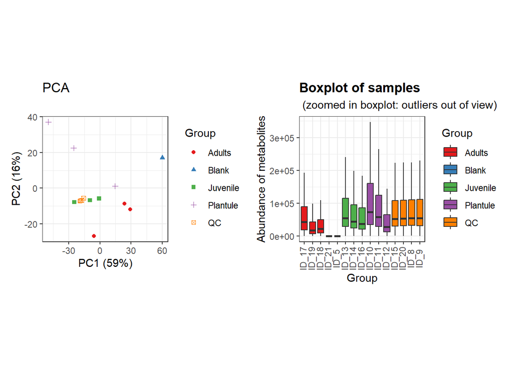

```r
POS_raw_sambx <- plot_sample_boxplots(Prueba_mode, order_by = "Group")
POS_raw_pca <- plot_pca(Prueba_mode, center = T)
POS_raw_pca + POS_raw_sambx
```

### Preprosesamiento con Mode

De acuerdo con el presente set de datos se tiene una sola columna cromatográfica (se puede verificar mediante names(modes)) y un modo de ionización (se puede verificar mediante sapply(modes, class)) se procede con la limpieza de datos. Primero, se reemplazará picos de abundancia cero (también pueden estar como 1 o 999), para ello previamente creamos una variable nombre para visualización de cada dato tratado y otra variable que contenga los datos de los objetos anteriormente creados (En este caso solo se tiene datos asociados a una columna cromatográfica RP_POS, pero si hubiera más de una columna se llamaría a cada una y luego se uniría los modes).

```r
# Variable para visualización del tratamiento
name <- names(modes)
# Llamado de datos RP_POS
mode <- modes$RP_POS
# Reemplaza abandancia cero por NA
mode <- mark_nas(mode, value = 0)
```

En la siguiente línea de código se procede con el agrupamiento de picos cromatográficos con baja tasa de detección. Donde qc_limit, filtra picos no detectados en los QC, por ejemplo, una valor del 75% con 4 QC’s nos dice que mantendrá aquellos picos cromatográficos que estén presentes en al menos 3 QC’s; de igual manera, en group_limit un porcentaje del 80% en muestras de 5 repeticiones nos dice que mantendrá picos que estén presentes en al menos 4 de las 5 repeticiones.En este caso se considerarán picos que estén presentes en al menos 3 de los 4 QC’s y en todos los triplicados de las muestras. Luego, se visualizarán los datos tratados (de ser necesario algunos paquetes deberán ser instalados).

```r
#Instalación de paquetes adicionales de ser necesario
if (!requireNamespace("devtools", quietly = TRUE)) {
  install.packages("devtools")
}
devtools::install_github("wilkelab/cowplot")
library(cowplot)

if (!requireNamespace("devtools", quietly = TRUE)) {
  install.packages("devtools")
}
devtools::install_github("jkrijthe/Rtsne")
library(Rtsne)

if (!requireNamespace("devtools", quietly = TRUE)) {
  install.packages("devtools")
}
devtools::install_github("andrie/ggdendro")
library(ggdendro)

# Parámetros para picos conservados en los QC's y las muestras
mode <- flag_detection(mode, qc_limit = 0.75, group_limit = 1)
# Visualización de datos corregidos por baja detección
visualizations(mode, prefix = paste0(ppath, "Figures/", name, "_PICOS-Constantes"))
```

El paso siguiente busca corregir la inestabilidad del equipo durante la lectura de muestras (Drift). La corrección de lectura del equipo, en la siguiente línea de código, se realiza mediante regresión de spline cúbico.

```r
corrected <- correct_drift(mode)
visualizations(corrected, prefix = paste0(ppath, "Figures/", name, "_DRIFT"))
```

Luego de la corrección del Drift, se procede con la agrupación de aquellos datos de baja calidad.

```r
corrected <- flag_quality(corrected)
visualizations(corrected, prefix = paste0(ppath, "Figures/", name, "_CLEANED"))
```

Se usará los blancos de procesamiento para agrupar posibles contaminantes.

```r
corrected <- flag_contaminants(corrected, blank_col = "Group", blank_label = "Blank", flag_thresh = 0.05, flag_label = "Contaminant")
visualizations(corrected, prefix = paste0(ppath, "Figures/", name, "_NOBlank"))
```

A continuación, los QC’s serán removidos, ya que, no será necesario en tratamientos posteriores, así como los blancos de procesamiento.

```r
corrected_no_qc <- drop_qcs(corrected)
visualizations(corrected_no_qc, prefix = paste0(ppath, "Figures/_NO_QC"))
```

Eliminando los blancos de procesamiento.

```r
corrected_no_blank <- corrected_no_qc[, corrected_no_qc$Group != "Blank"]
pData(corrected_no_blank) <- droplevels(pData(corrected_no_blank))
corrected_no_blank

visualizations(corrected_no_blank, prefix = paste0(ppath, "Figures/_NO_Blank"))
```

De acuerdo con características quimio-métricas semejantes algunos picos pueden ser agrupados para reducir la representación redundante de los mismos. Por ejemplo, picos con diferentes aductos puede ser agrupados para un mismo compuesto. El paquete Notame permite la agrupación de estos mediante el siguiente código.

```r
# Instalación del paquete igraph de ser necesario
if (!requireNamespace("devtools", quietly = TRUE)) {
  install.packages("devtools")
}
devtools::install_github("igraph/rigraph")
library(igraph)
# Instalación del paquete ggrepel de ser necesario
if (!requireNamespace("devtools", quietly = TRUE)) {
  install.packages("devtools")
}
devtools::install_github("slowkow/ggrepel")
library(ggrepel)

# Establecimiento de los clústeres
clustered <- cluster_features(corrected_no_blank, rt_window = 1/60, corr_thresh = 0.9, d_thresh = 0.8, plotting = TRUE, prefix = paste0(ppath, "Cluster/_NO_QC_Blank"))

# Extracción del pico representativo de cada clúster
compressed <- compress_clusters(clustered)

# Vizualización de datos tratados
visualizations(compressed, prefix = paste0(ppath, "Figures/_Compr"))
```

Imputación de valores perdidos mediante una búsqueda aleatoria para garantizar la reproducibilidad de los datos.

```r
# De ser necesario instalar el paquete missForest
if (!requireNamespace("devtools", quietly = TRUE)) {
  install.packages("devtools")
}
devtools::install_github("stekhoven/missForest")
library(missForest)

# Valor aleatorio para grarantizar la reproducibilidad
set.seed(57)
imputed <- impute_rf(compressed)
```

La imputación anterior aplicó únicamente para datos de buena calidad, en el siguiente código se imputan datos agrupados como de baja calidad.

```r
imputed <- impute_rf(imputed, all_features = TRUE)

#Visualización de datos tratados
visualizations(imputed, prefix = paste0(ppath, "Figures/_Mising-Value"))
```

De esta manera los datos están listos para ser exportados y proceder con los análisis estadísticos.

```r
save(imputed, file = paste0(ppath, "full_POS_data.RData"))
```

### Análisis multivariable ACP

Para una mejor representación del Análisis de Componentes Principales (ACP) se procede a eliminar datos de baja calidad.

```r
no_flag <- drop_flagged(imputed)

# Extracción de los datos de abundancia de picos (área en este caso)
peak_area <- exprs(no_flag)

# Extracción de la información de las muestras
muestras_Info <- no_flag@phenoData@data
```

A continuación se preparan los datos a graficar.

```r
trans_varia  <- t(peak_area)

# Remplazando valores de NA por cero 0
trans_varia[is.na(trans_varia)]=0

# Centrado y escalado de los datos para el ACP
acp_pos_Pablo <- prcomp(trans_varia, center = T, scale. = T)
```

Obtención de las cordenadas para la gráfica del PCA.

```r
# De ser necesario instale el paquete dplyr
library(dplyr)

scores <- acp_pos_Pablo$x %>%               # Obtención de los puntajes
  data.frame %>%                            # Conversión a datos de dos dimenciones
  mutate(Sample_ID = rownames(.)) %>%       # Creación de una columna para las muestras
  left_join(muestras_Info)                  # etiqueta de las muestras en columna anterior
```

Graficación del plano principal del ACP.

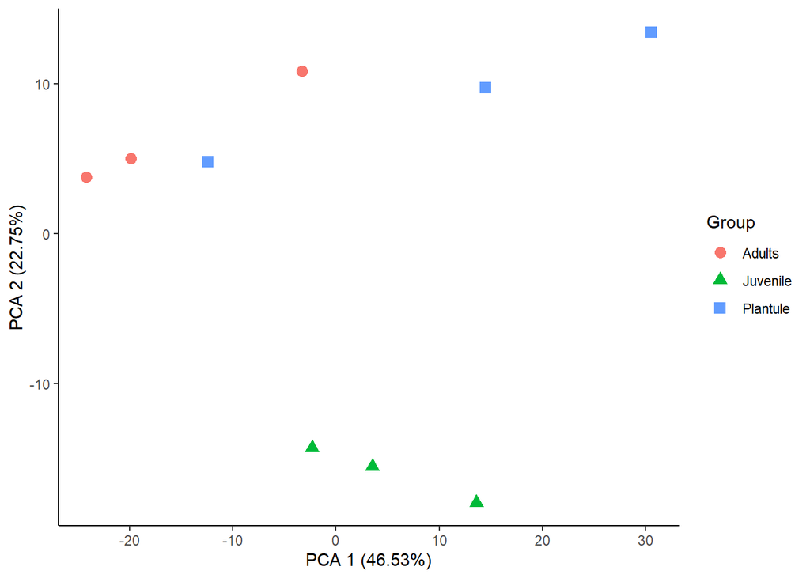

```r
ggplot(scores, aes(PC1, PC2, shape = Group, color = Group)) +
  geom_point(size = 3) +
  guides(x=guide_axis(title = "PCA 1 (46.53%)"), y=guide_axis(title = "PCA 2 (22.75%)")) +
  theme_classic()
```

```r
# Se puede ejecutar el siguiente código para ver la inercia acumulada de cada componente:
# summary(acp_pos_Pablo)
```

Para el gráfico del círculo de correlaciones, se procede con la abtención de las cordenadas de cada variable o metabolito en este caso.

```r
loadings <- acp_pos_Pablo$rotation %>%    # Obtención de las coordenadas
  data.frame(Feature_name = rownames(.))  # Nueva columna para los metabolitos
```

```r
# De ser necesario instale el paquete readxl
if (!requireNamespace("devtools", quietly = TRUE)) {
  install.packages("devtools")
}
devtools::install_github("tidyverse/readxl")
library(readxl)

metabolites_name <- readxl::read_excel("Pablo-Compounds-POS.xlsx", 2)
head(metabolites_name)
```

La siguiente línea de código combina la primera columna del Excel de metabolitos de manera que aquellos picos identificados tengan su respectivo nombre en la matriz de correlaciones.

```r
picos_iden <- left_join(metabolites_name, loadings)
```

Se procederá a graficar el círculo de correlaciones.

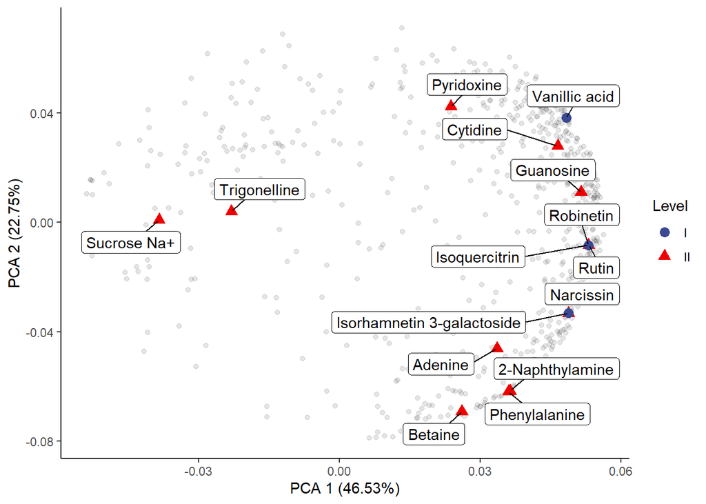

```r
# De ser neceario instale el paquete ggsci
if (!requireNamespace("devtools", quietly = TRUE)) {
  install.packages("devtools")
}
devtools::install_github("nanxstats/ggsci")
library(ggsci)

ggplot(loadings, aes(PC1, PC2)) +
  geom_point(alpha = 0.1) +
  theme_classic() +
  geom_point(data = picos_iden, aes(shape = Level, color = Level),
             size = 3) +
  ggrepel::geom_label_repel(data = picos_iden,
                            aes(label = Compound),
                            box.padding = 0.5) +
  guides(x=guide_axis(title = "PCA 1 (46.53%)"), y=guide_axis(title = "PCA 2 (22.75%)")) +
  ggsci::scale_color_aaas()
```

Finalmente, se culmina el proyecto y, por ende, el historial.

```r
finish_log()
```

[output not shown]